# Exercício aula 08 resolução detalhamento veículos

Rafael De Pauli Baptista, Vinícius Hayashi Abreu, Fernando Albani

11/06/2024

# 1. Entendimento inicial do dataset

Segue informações gerais dos campos do dataset

```
##      Make              Model           Vehicle.Class      Engine.Size.L.
##  Length:7385        Length:7385        Length:7385        Min.   :0.90
##  Class :character   Class :character   Class :character   1st Qu.:2.00
##  Mode  :character   Mode  :character   Mode  :character   Median :3.00
##                                                           Mean   :3.16
##                                                           3rd Qu.:3.70
##                                                           Max.   :8.40
##    Cylinders      Transmission        Fuel.Type
##  Min.   : 3.000   Length:7385        Length:7385
##  1st Qu.: 4.000   Class :character   Class :character
##  Median : 6.000   Mode  :character   Mode  :character
##  Mean   : 5.615
##  3rd Qu.: 6.000
##  Max.   :16.000
##  Fuel.Consumption.City..L.100.km. Fuel.Consumption.Hwy..L.100.km.
##  Min.   : 4.20                    Min.   : 4.000
##  1st Qu.:10.10                    1st Qu.: 7.500
##  Median :12.10                    Median : 8.700
##  Mean   :12.56                    Mean   : 9.042
##  3rd Qu.:14.60                    3rd Qu.:10.200
##  Max.   :30.60                    Max.   :20.600
##  Fuel.Consumption.Comb..L.100.km. Fuel.Consumption.Comb..mpg.
##  Min.   : 4.10                    Min.   :11.00
##  1st Qu.: 8.90                    1st Qu.:22.00
##  Median :10.60                    Median :27.00
##  Mean   :10.98                    Mean   :27.48
##  3rd Qu.:12.60                    3rd Qu.:32.00
##  Max.   :26.10                    Max.   :69.00
##  CO2.Emissions.g.km.
##  Min.   : 96.0
##  1st Qu.:208.0
##  Median :246.0
##  Mean   :250.6
##  3rd Qu.:288.0
##  Max.   :522.0
```

# Gráficos para entendimento inicial

## Bloxplot num. cilindros de todos os carros

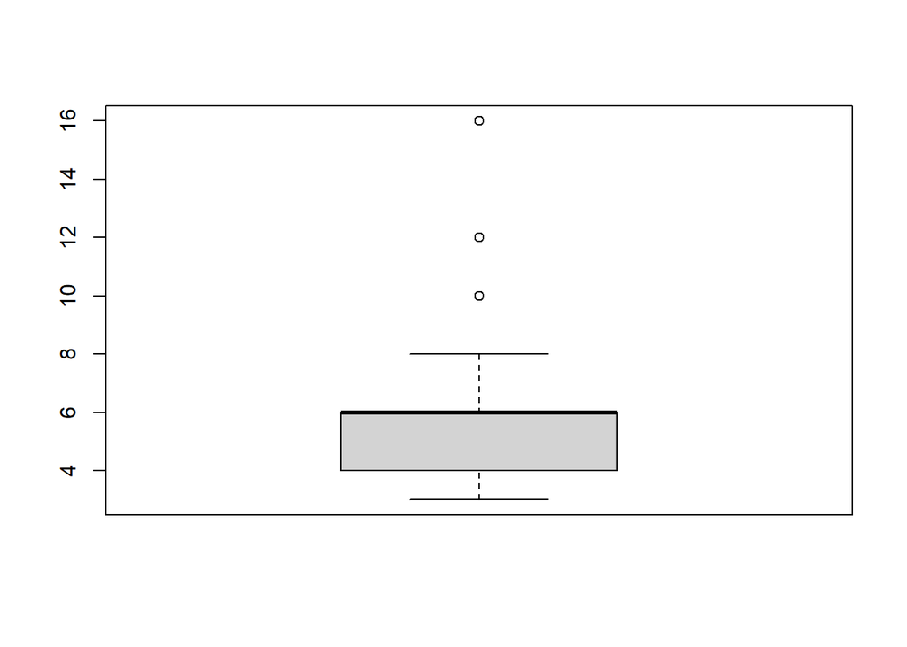

**Interpretação:**

- 1º quartil: 4 cilindros
- 2º quartil ou mediana: 6 cilindros
- 3º quartil: 6 cilindros
- Máximo: 16 cilindros

Gráfico detalha melhor as informações do item **Entendimento inicial do dataset**

```
## # A tibble: 20 × 5
##    Cylinders Fuel.Type consumo_medio desvio_padrao  qtde
##        <int> <chr>             <dbl>         <dbl> <int>
##  1         3 X                  6.89         0.809    37
##  2         3 Z                  7.89         0.801    58
##  3         4 D                  8.02         1.59     89
##  4         4 X                  8.54         1.42   2111
##  5         4 Z                  9.29         0.943   966
##  6         6 D                  9.68         0.950    86
##  7         5 X                 10.1          0.514    20
##  8         5 Z                 10.4          0.121     6
##  9         6 Z                 11.0          1.24   1159
## 10         6 X                 11.6          1.20   1041
## 11         4 E                 12.5          1.41     54
## 12         6 N                 12.7         NA         1
## 13         8 Z                 13.6          1.49    818
## 14         8 X                 14.1          1.70    427
## 15        10 Z                 15.4          1.05     41
## 16         6 E                 16.1          1.41    159
## 17        12 Z                 16.3          1.75    151
## 18         8 E                 19.1          2.23    157
## 19        10 X                 21.2         NA         1
## 20        16 Z                 22.2          0         3
```

**Interpretação:**

- Para um mesmo tipo de combustível, quanto maior a quantidade de cilindros, maior o consumo_medio
- O tipo mais econômico é o carro com **3 cilindros**, tipo de combustível **X**.
- O tipo mais popular são os carros de **4 cilindros** e tipo de combustível **X**.